# 1. Calculus Review

MAT321 Numerical Analysis

Cheng Peng

# 1 Introduction

This note reviews the basics of Calculus which will be used throughout the semester. We will not derive or prove anything in this note.

# 2 Limits and Continuity

The concept of continuity of function is defined based on the concept of the limit of a function at a given point. They are core concepts in numerical analysis. We use $\epsilon\text{-}\delta$ language to summarize the limits and continuity. We only use single-variable functions to describe these concepts.

## 2.1 Limits

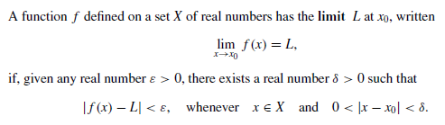

This definition can be graphically explained in the following figure

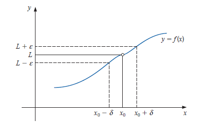

## 2.2 Continuity

The continuity of a function is defined based on the concept of limit.

**Definition**: Let $f$ be a function defined on a set $X$ of real numbers and $x_0 \in X$. Then $f$ is continuous at $x_0$ if
$$\lim_{x\to x_0}f (x) = f (x_0).$$
The function $f$ is continuous on the set $X$ if it is continuous at each number in $X$.

## 2.3 Convergence of A Sequence

Convergence is one of the fundamental concepts in numerical analysis which is related to the limit of a sequence of real or complex numbers. In numerical analysis, the order of convergence and the rate of convergence of a convergent sequence are quantities that represent how quickly the sequence approaches its limit.

**Definition**: Let $\{x_n\}^\infty_{n=1}$ be an infinite sequence of real numbers. This sequence has the **limit x (converges to x)** if, for any $\epsilon > 0$ there exists a positive integer $N(\epsilon)$ such that $|x_n-x|<\epsilon$, whenever $n > N(\epsilon)$. The notation
$$\lim_{n \to\infty}x_n = x, \text{ or } x_n \to x \text{ as } n\to
\infty,$$
means that the sequence $\{x_n\}^\infty_{n=1}$ converges to $x$.

**Definition**: If $f$ is a function defined on a set $X$ of real numbers and $x_0 \in X$, then the following statements are equivalent:

1. $f$ is continuous at $x_0$;
2. If $\{x_n\}^\infty_{n=1}$ is any sequence in $X$ converging to $x_0$, then $lim_{n\to \infty} f (x_n) = f (x_0)$.

*Remark*: The values of above sequences in $X$ could be from both sides of $x_0$.

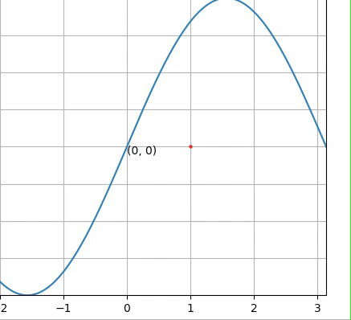

# 3 Differentiation

In numerical analysis, many numerical algorithms are based on the assumption that the curve of the underlying function is continuous and **smooth** over an interval. The smoothness of a curve is characterized by the concept of differentiation.

## 3.1 Definition

**(Average) Rate of Change**: The rate of change of a function $f(x)$ over interval $[x, x+\Delta x]$ is defined to be
$$\frac{f(x+\Delta x) - f(x)}{\Delta}$$

Geometrically, the average rate of change of $f(x)$ over the interval is the slope of the secant line that passes through the two points on the curve corresponding to the two ending values of the interval.

**Definition**: Let $f$ be a function defined in an open interval containing $x_0$. The function f is differentiable at $x_0$ if
$$f^\prime(x_0) = \lim_{x\to x_0}\frac{f (x)-f (x_0)}{x-x_0}$$

exists. The number $f(x_0)$ is called the derivative of $f$ at $x_0$. A function that has a derivative at each number in a set $X$ is differentiable on $X$.

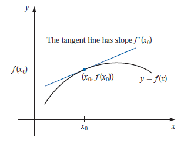

We will assume that you are proficient in using all rules of derivatives. Particularly, the power and chain rules.

## 3.2 Properties

Some of the properties and existence theorems will be used in developing numerical algorithms for optimization.

**Rolle’s Theorem**: Suppose $f \in C[a, b]$ (continuous) and $f$ is differentiable on $(a, b)$. If $f (a) = f (b)$, then a number $c$ in $(a, b)$ exists with $f(c) = 0$.

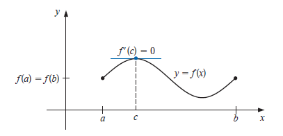

The following mean value theorem is a generalization of Rolle’s Theorem.

**Mean Value Theorem**: If $f \in C[a, b]$ and f is differentiable on $(a, b)$, then a number $c$ in $(a, b)$ exists with
$$\frac{f(b) - f(a)}{b - a}.$$
We can visualize the mean value theorem in the following figure.

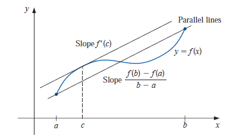

**Extreme Value Theorem**: If $f \in C[a, b]$, then $c_1, c_2 \in [a, b]$ exist with $f (c_1) \le f (x) \le f (c_2)$, for all $x \in [a, b]$. In addition, if $f$ is differentiable on $(a, b)$, then the numbers $c_1$ and $c_2$ occur either at the endpoints of $[a, b]$ or where $f$ is zero.

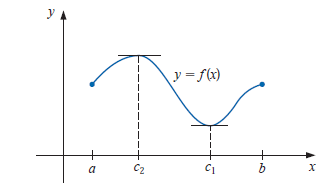

**Example 1**: Use a computer program to find the absolute minimum and absolute maximum values of
$$f (x) = 5 \cos (2x) - 2x \sin (2x)$$
on the intervals $[1, 2]$ and $[0.5, 1]$, respectively.

**Solution**: We could free online graphing tools such as *WolframAlpha* (https://www.wolframalpha.com/) to sketch the function. We will use **R** to plot the function.

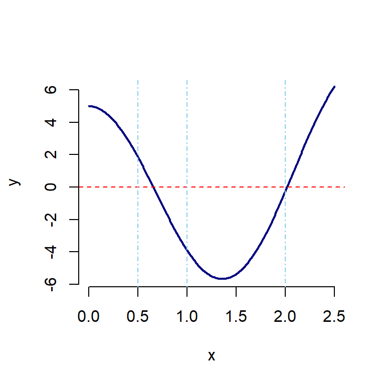

```r
x=seq(0, 2.5, by = 0.01)
y=5*cos(2*x) - 2*x*sin(2*x)
plot(x,y, type="l", lwd=2, col="navy", bty="n")
abline(h=0, lty=2, col="red")
abline(v=c(0.5, 1, 2), lty=4, col="skyblue")
```

(a). We can see from the above figure that, the absolute maximum on $[1, 2]$ is $f(2) = 5\cos(2\times 2) - 2\times 2 \sin(2\times 2) = -0.2410081$ (see the following code)

```r
5*cos(4) - 4*sin(4)
```

```
## [1] -0.2410081
```

```r
# install and load the R package to use the built-in functions
#if (!require("nleqslv")) {
#   install.packages("nleqslv")
#   library(nleqslv)
#}
##
fn = function(x) tan(2*x)+x/3  # define the function
root = nleqslv(1.5, fn)$x      # the first list $x in the output is the root
f.min = 5*cos(2*root) - 2*root*sin(2*root)  # finding the absolute minimum
list(root = root, abs.min = f.min)
```

```
## $root
## [1] 1.35823
##
## $abs.min
## [1] -5.675301
```

(2). Since the function is strictly decreasing on $[0.5, 1]$, to find the absolute minimum and maximum of the function on $[0.5, 1]$, we simply evaluate the function at $x = 0.5$ and $x = 1$ (see the following code).

```r
list(abs.max = 5*cos(2*0.5) - 2*0.5*sin(2*0.5),
     abs.min = 5*cos(2*1) - 2*1*sin(2*1))
```

```
## $abs.max
## [1] 1.860041
##
## $abs.min
## [1] -3.899329
```

Therefore, the absolute minimum is $f(1) = -3.899329$ and the absolute maximum $f(0.5) = 1.860041$.

**Intermediate Value Theorem**: If $f \in C[a, b]$ and $K$ is any number between $f (a)$ and $f (b)$, then there exists a number $c$ in $(a, b)$ for which $f (c) = K$.

The results in intuitive from the following figure.

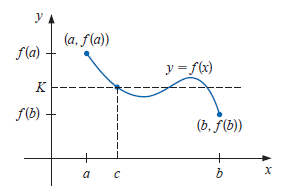

**Example 2**: Show that $x^5 - 2x^3 + 3x^2 - 1 = 0$ has a solution in the interval $[0, 1]$.

**Solution**: We want to prove the *existence* of a solution in $[0, 1]$. We first sketch the function in the following.

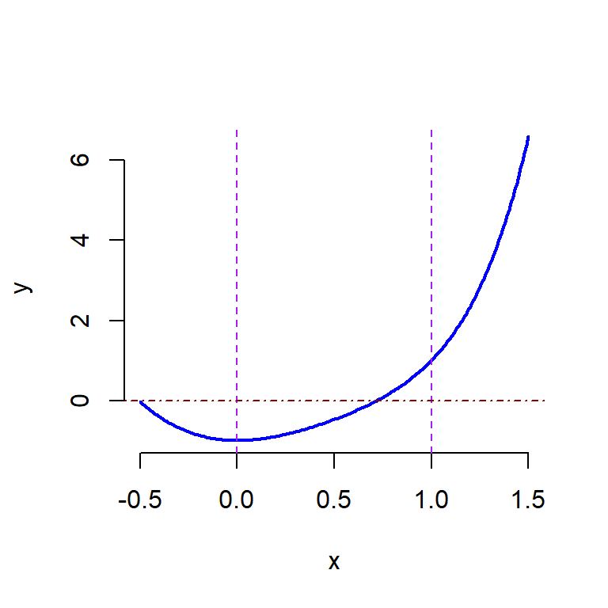

```r
x = seq(-0.5, 1.5, by =0.01)
y = x^5-2*x^3 + 3*x^2-1
plot(x,y, type="l", lwd=2, col="blue", bty="n")
abline(v=c(0,1), lty = 2, col = "purple")
abline(h=0, lty = 4, col="darkred")
```

After inspecting the curve, choose $a = 0$ and $b = 1$ and then use the intermediate value theorem. Note that $f(0) = -1$ and $f(1) = 1$. Therefore, $f(x) = 0$ has a solution in $[0,1]$.

**Remark**: The intermediate value theorem states that the existence of *at least one solution* in interval $[a, b]$.

# 4 Integration

Numerical integration is one of the major topics in numerical analysis. We focus on the definite integral of the single variable function.

## 4.1 Series vs Sequence

A **sequence** is an arrangement of any objects or a set of numbers in a particular order followed by some rule. If $a_1, a_2, a_3, a_4,\cdots$, denote the terms of a sequence, then $1,2,3,4, \cdots$ denotes the position of the term. A sequence can be defined based on the number of terms i.e. either finite sequence or infinite sequence.

If $a_1, a_2, a_3, a_4,\cdots$ is a sequence, then the corresponding **series** is given by $S_n = a_1+a_2+a_3 + \cdots + a_n$ for $n = 1, 2, \cdots,$. If $\lim_{n \to \infty} s_n = A$ ($A$ is finite), then we call series $s_n$ converges to $A$.

## 4.2 Definition of Definite Integral

**Riemann Integral**: The Riemann integral of the function $f$ on the interval $[a, b]$ is the following limit, provided it exists:
$$\int_a^bf(x) dx = \lim_{\max \Delta x_i \to 0} \sum_{i=1}^n f(z_i)\Delta
x_i,$$
where the numbers $x_0, x_1, \cdots , x_n$ satisfy $a = x_0 \le x_1 \le \cdots \le x_n = b$, where $x_i = x_i - x_{i-1}$, for each $i = 1, 2, \cdots, n$, and $z_i$ is arbitrarily chosen in the interval $[x_{i-1}, x_i]$.

**Remark1**: The above Riemann integral involves two concepts

1. **Partition of an interval**: $a = x_0 \le x_1 \le \cdots \le x_n = b$ is also called a partition of interval $[a,b]$.
2. $D_n = \sum_{i=1}^n f(z_i)\Delta x_i$ is so called Darboux sum.

In practice, we take a simple **equally spaced partition** to evaluate the Riemann integral. To be specific, use the partition such that $x_i = a + i(b-a)/n$. With this equally-spaced partition, the Riemann integral has the following simple form
$$\int_a^b f(x) dx = \lim_{n \to \infty}\frac{b-a}{n}\sum_{i=1}^nf(x_i),$$
The geometric display of the Darboux in the above expression is given below

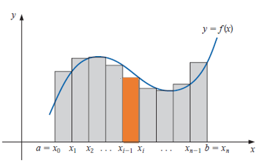

The area of the orange rectangle is the i-th term in the Darboux sum.

The following animated graph shows the process of approximating the integral by the Darboux sum.

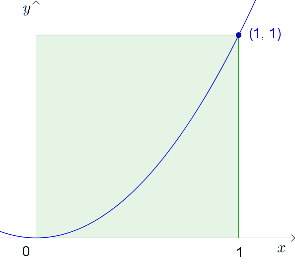

## 4.3 Taylor Expansion

Since polynomial functions are relatively easier to handle in mathematics. If we want to study the *local* behavior of a complicated function (algebraically), we could use a polynomial to approximate the function locally. The Taylor series is one such polynomial that is used frequently in practice.

**Taylos’s Theroem**: Suppose $f \in C^n[a,b]$, that $f^{(n+1)}$ exists on $[a,b]$, and $x_0 \in [a,b]$. For every $x \in [a,b]$, there exists a number $\xi(x)$ between $x_0$ and $x$ with

$$f(x) = P_n(x) + R_n(x),$$
where
$$P(x) = f(x_0) + f^\prime(x_0)(x -
x_0)+\frac{f^{\prime\prime}(x_0)}{2!}(x-x_0)^2+\cdots+\frac{f^{(n)}(x_0)}{n!}(x-x_0)^n$$
$$=\sum_{k=0}^n\frac{f^{(k)}(x_0)}{k!}(x-x_0)^k.$$
and
$$R_n(x) = \frac{f^{(n+1)}(\xi(x))}{(n+1)!}(x-x_0)^{n+1}.$$

Here $P_n(x)$ is called the **nth Taylor polynomial** for f about $x_0$, and $R_n(x)$ is called the **remainder term (or truncation error)** associated with $P_n(x)$.

When $x_0 = 0$, the Taylor polynomial is called **Maclaurin polynomial**.

**Example**: Let $f (x) = cos x$ and $x_0 = 0$. Determine the second Taylor polynomial for $f$ about $x_0$.

**Solution**: We use the Taylor theorem to expand $cos(x)$ up two 2nd order
$$cos(x) = f(0) +
f^\prime(0)x+\frac{f^{\prime\prime}(0)}{2!}x^2+\frac{f^{(\xi(x))}(0)}{3!}x^3$$
$$=1 - \frac{1}{2}x^2+\frac{1}{6}x^3\sin[\xi(x)].$$
where $\xi(x)$ is in $[0, x]$. The following figure shows the approximation.

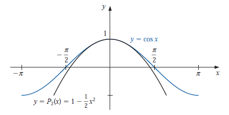

# 5 Homework [Part One]

This is the first part of the Chapter #1 assignment. The second part of the problem set will be given next week. All problems are selected from the required textbook.

**Submission Requirements**: All written submission must be through D2L. There are three different ways for preparing your submission;

1. You are strongly encouraged to submit an electronic version (PDF) generated by the RMarkdown document to the D2L dropbox as a single file.
2. You can prepare your work using the RMarkdown and then publish your completed work on RPubs. You can then simply provide a link to your solutions.
3. You could also write your solutions by hand and then scan them to make a single file. Upload your file to the D2L drop box.

**Chapter One Homework due**: Monday, 2/6 (before class meeting).

**Problems**: Section 1.1: 1(a), 4(b), 11(a), 19, and 27.